# MERDs Bacterial Community Analyses

##### Graph for publication

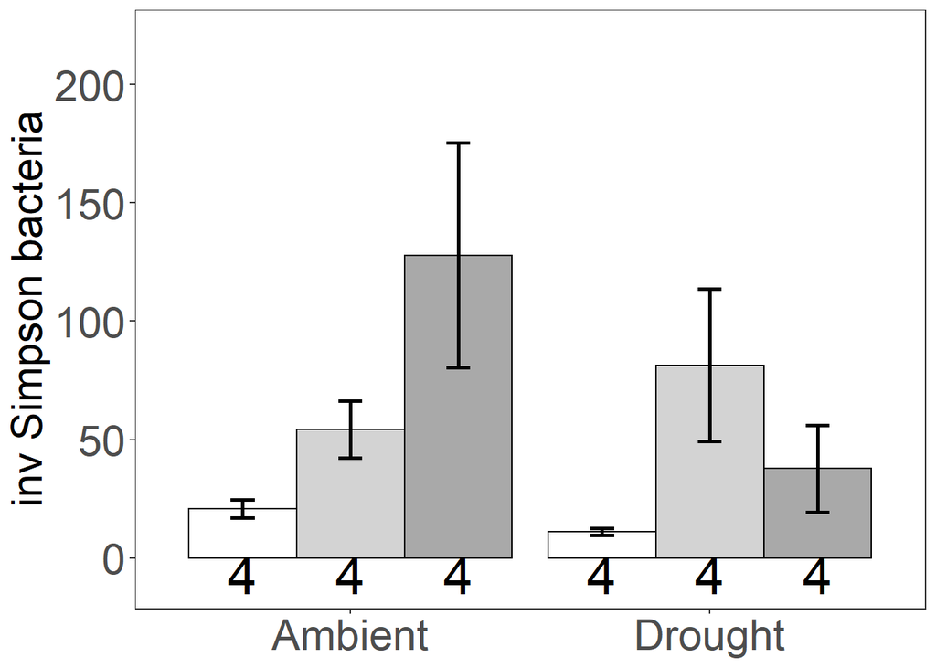

### Presence inv Simpson

Diagnostic Graphs

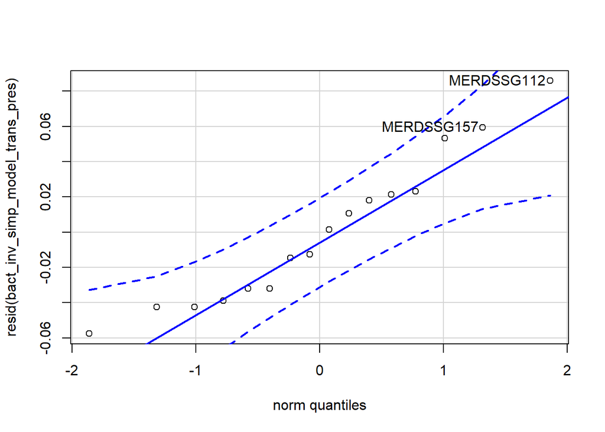

```
## MERDSSG112 MERDSSG157
##          2         10
```

```r
SILVA_MERDS_rar.divfil_pres_trans=subset(SILVA_MERDS_rar.divfil_trt_trans, root_association =="B")

bact_inv_simp_model_trans_pres= lmer((InvSimpson)^(-1/2)~soil_root*precip+(1|block), data= SILVA_MERDS_rar.divfil_pres_trans)
qqPlot(resid(bact_inv_simp_model_trans_pres))
```

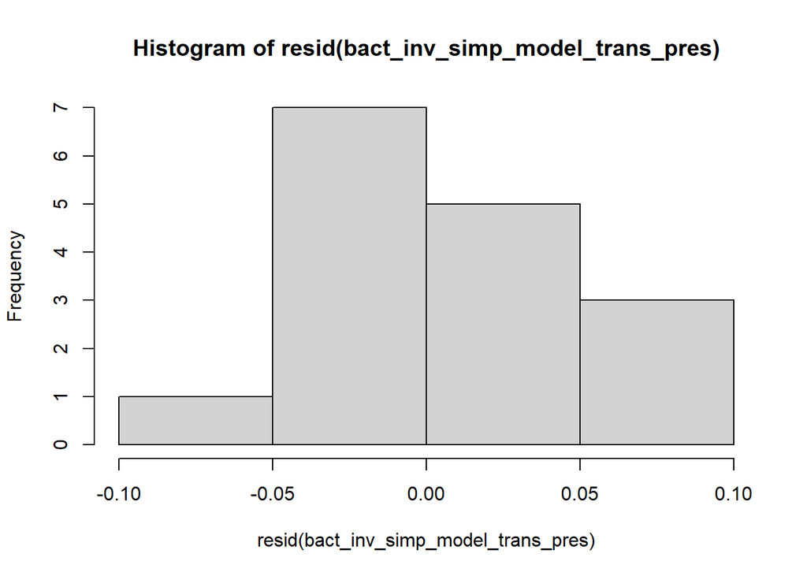

```r
hist(resid(bact_inv_simp_model_trans_pres))
```

```r
shapiro.test(resid(bact_inv_simp_model_trans_pres))
```

```
##
##  Shapiro-Wilk normality test
##
## data:  resid(bact_inv_simp_model_trans_pres)
## W = 0.94386, p-value = 0.399
```

Raw Statistical output

```r
anova(bact_inv_simp_model_trans_pres)
```

```
## Type III Analysis of Variance Table with Satterthwaite's method
##                    Sum Sq  Mean Sq NumDF DenDF F value    Pr(>F)
## soil_root        0.058495 0.058495     1     9 25.1118 0.0007278 ***
## precip           0.005318 0.005318     1     9  2.2832 0.1650705
## soil_root:precip 0.007404 0.007404     1     9  3.1784 0.1082930
## ---
## Signif. codes:  0 '***' 0.001 '**' 0.01 '*' 0.05 '.' 0.1 ' ' 1
```

```r
emmeans(bact_inv_simp_model_trans_pres, pairwise~soil_root|precip)
```

```
## Note: Use 'contrast(regrid(object), ...)' to obtain contrasts of back-transformed estimates
```

```
## $emmeans
## precip = A:
##  soil_root emmean     SE   df lower.CL upper.CL
##  L.B        0.148 0.0253 11.7   0.0931    0.203
##  S.B        0.226 0.0253 11.7   0.1710    0.281
##
## precip = D:
##  soil_root emmean     SE   df lower.CL upper.CL
##  L.B        0.142 0.0253 11.7   0.0865    0.197
##  S.B        0.306 0.0253 11.7   0.2505    0.361
##
## Degrees-of-freedom method: kenward-roger
## Results are given on the ( (not the response) scale.
## Confidence level used: 0.95
##
## $contrasts
## precip = A:
##  contrast  estimate     SE df t.ratio p.value
##  L.B - S.B  -0.0779 0.0341  9 -2.283  0.0483
##
## precip = D:
##  contrast  estimate     SE df t.ratio p.value
##  L.B - S.B  -0.1640 0.0341  9 -4.804  0.0010
##
## Note: contrasts are still on the ( scale
## Degrees-of-freedom method: kenward-roger
```

Formatted Anova table

Presence Transplant soil communtiy inv Simpson

|  | Df | Resid.Df | F.value | P.value |
| --- | --- | --- | --- | --- |
| soil_root | 1 | 9 | 25.11 | 0.001 |
| precip | 1 | 9 | 2.28 | 0.165 |
| soil_root:precip | 1 | 9 | 3.18 | 0.108 |

### Origin inv Simpson

Diagnostic Graphs

```r
SILVA_MERDS_rar.divfil_orig_trans=subset(SILVA_MERDS_rar.divfil_trt_trans, soil_status =="L")

bact_inv_simp_model_trans_orig= lmer((InvSimpson)~soil_root*precip+(1|block), data= SILVA_MERDS_rar.divfil_orig_trans)
```

```
## boundary (singular) fit: see ?isSingular
```

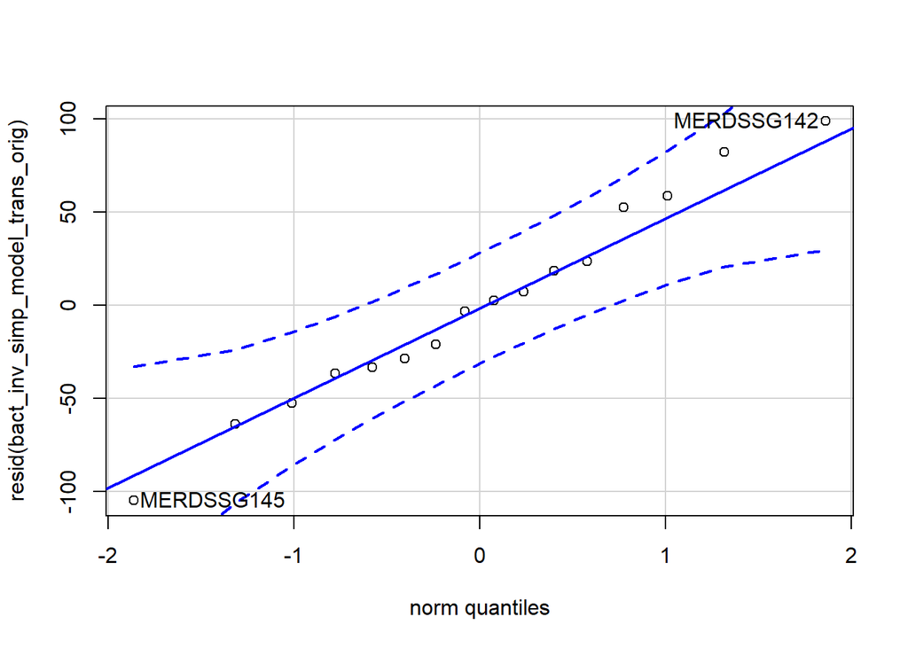

```
## MERDSSG145 MERDSSG142
##          9          8
```

```r
qqPlot(resid(bact_inv_simp_model_trans_orig))
```

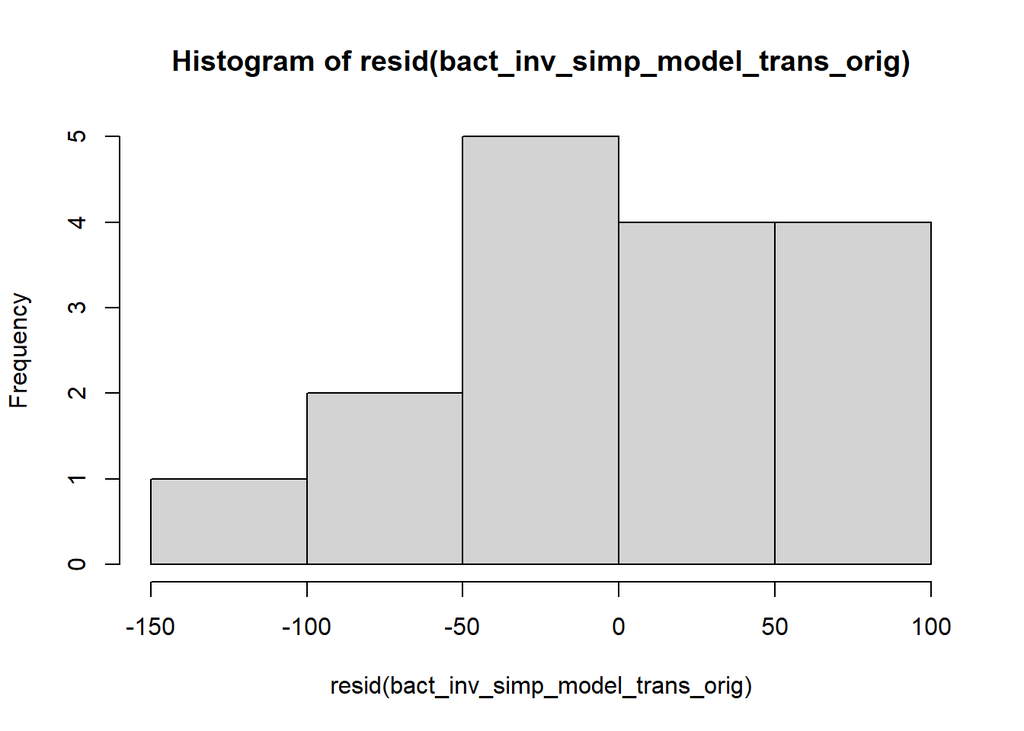

```r
hist(resid(bact_inv_simp_model_trans_orig))
```

```r
shapiro.test(resid(bact_inv_simp_model_trans_orig))
```

```
##
##  Shapiro-Wilk normality test
##
## data:  resid(bact_inv_simp_model_trans_orig)
## W = 0.98535, p-value = 0.9921
```

Raw Statistical output

```r
anova(bact_inv_simp_model_trans_orig)
```

```
## Type III Analysis of Variance Table with Satterthwaite's method
##                   Sum Sq Mean Sq NumDF DenDF F value  Pr(>F)
## soil_root          896.9   896.9     1    12  0.2377 0.63464
## precip            3969.5  3969.5     1    12  1.0521 0.32526
## soil_root:precip 13800.8 13800.8     1    12  3.6577 0.07997 .
## ---
## Signif. codes:  0 '***' 0.001 '**' 0.01 '*' 0.05 '.' 0.1 ' ' 1
```

```r
emmeans(bact_inv_simp_model_trans_orig, pairwise~soil_root|precip)
```

```
## Note: Use 'contrast(regrid(object), ...)' to obtain contrasts of back-transformed estimates
```

```
## $emmeans
## precip = A:
##  soil_root emmean   SE df lower.CL upper.CL
##  L.B         54.2 30.7 12    -12.7      121
##  L.R        127.9 30.7 12     61.0      195
##
## precip = D:
##  soil_root emmean   SE df lower.CL upper.CL
##  L.B         81.4 30.7 12     14.5      148
##  L.R         37.7 30.7 12    -29.3      105
##
## Degrees-of-freedom method: kenward-roger
## Results are given on the ( (not the response) scale.
## Confidence level used: 0.95
##
## $contrasts
## precip = A:
##  contrast  estimate   SE df t.ratio p.value
##  L.B - L.R    -73.7 43.4  9 -1.697  0.1239
##
## precip = D:
##  contrast  estimate   SE df t.ratio p.value
##  L.B - L.R     43.8 43.4  9  1.008  0.3400
##
## Note: contrasts are still on the ( scale
## Degrees-of-freedom method: kenward-roger
```

Formatted Anova table

|  | Df | Resid.Df | F.value | P.value |
| --- | --- | --- | --- | --- |
| soil_root | 1 | 12 | 0.24 | 0.635 |
| precip | 1 | 12 | 1.05 | 0.325 |
| soil_root:precip | 1 | 12 | 3.66 | 0.080 |

### Seed Richness

Diagnostic Graphs

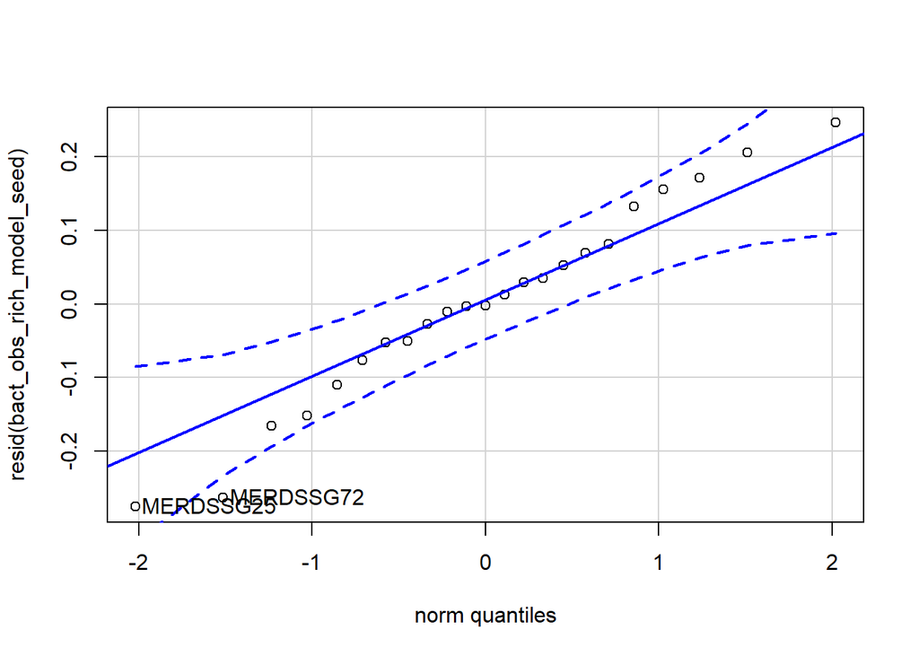

```
## MERDSSG25 MERDSSG72
##         5        18
```

```r
bact_obs_rich_model_seed= lmer(log(Observed)~soil_root*precip+(1|block), data= SILVA_MERDS_rar.divfil_trt_seed)
qqPlot(resid(bact_obs_rich_model_seed))
```

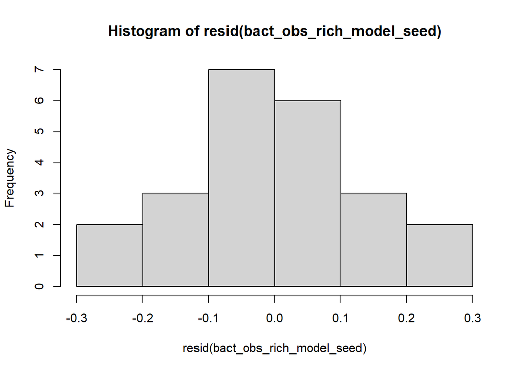

```r
hist(resid(bact_obs_rich_model_seed))
```

```r
shapiro.test(resid(bact_obs_rich_model_seed))
```

```
##
##  Shapiro-Wilk normality test
##
## data:  resid(bact_obs_rich_model_seed)
## W = 0.97783, p-value = 0.866
```

Raw Statistical output

```r
anova(bact_obs_rich_model_seed)
```

```
## Type III Analysis of Variance Table with Satterthwaite's method
##                   Sum Sq Mean Sq NumDF  DenDF  F value    Pr(>F)
## soil_root        18.1186  9.0593     2 15.160 355.6853 1.825e-13 ***
## precip            0.0405  0.0405     1 14.304   1.5890    0.2276
## soil_root:precip  0.0354  0.0177     2 15.160   0.6958    0.5139
## ---
## Signif. codes:  0 '***' 0.001 '**' 0.01 '*' 0.05 '.' 0.1 ' ' 1
```

```r
emmeans(bact_obs_rich_model_seed, pairwise~soil_root|precip)
```

```
## $emmeans
## precip = A:
##  soil_root emmean     SE   df lower.CL upper.CL
##  L.B         6.93 0.0831 16.3     6.76     7.11
##  S.B         5.21 0.0831 16.3     5.03     5.38
##  L.R         7.23 0.0831 16.3     7.06     7.41
##
## precip = D:
##  soil_root emmean     SE   df lower.CL upper.CL
##  L.B         6.90 0.0831 16.3     6.72     7.08
##  S.B         5.01 0.1055 15.3     4.78     5.23
##  L.R         7.21 0.0881 15.2     7.03     7.40
##
## Degrees-of-freedom method: kenward-roger
## Results are given on the log (not the response) scale.
## Confidence level used: 0.95
##
## $contrasts
## precip = A:
##  contrast  estimate    SE   df t.ratio p.value
##  L.B - S.B    1.724 0.113 14.0  15.276 <.0001
##  L.B - L.R   -0.301 0.113 14.0  -2.668 0.0454
##  S.B - L.R   -2.025 0.113 14.0 -17.945 <.0001
##
## precip = D:
##  contrast  estimate    SE   df t.ratio p.value
##  L.B - S.B    1.893 0.130 15.8  14.541 <.0001
##  L.B - L.R   -0.312 0.117 14.9  -2.680 0.0428
##  S.B - L.R   -2.206 0.142 17.0 -15.561 <.0001
##
## Degrees-of-freedom method: kenward-roger
## Results are given on the log (not the response) scale.
## P value adjustment: tukey method for comparing a family of 3 estimates
```

```r
emmeans(bact_obs_rich_model_seed, pairwise~soil_root)
```

```
## NOTE: Results may be misleading due to involvement in interactions
```

```
## $emmeans
##  soil_root emmean     SE   df lower.CL upper.CL
##  L.B         6.92 0.0610 10.7     6.78     7.05
##  S.B         5.11 0.0691 10.9     4.96     5.26
##  L.R         7.22 0.0627 10.1     7.08     7.36
##
## Results are averaged over the levels of: precip
## Degrees-of-freedom method: kenward-roger
## Results are given on the log (not the response) scale.
## Confidence level used: 0.95
##
## $contrasts
##  contrast  estimate     SE   df t.ratio p.value
##  L.B - S.B    1.809 0.0861 15.1  20.994 <.0001
##  L.B - L.R   -0.307 0.0811 14.5  -3.782 0.0051
##  S.B - L.R   -2.115 0.0906 16.3 -23.351 <.0001
##
## Results are averaged over the levels of: precip
## Degrees-of-freedom method: kenward-roger
## Results are given on the log (not the response) scale.
## P value adjustment: tukey method for comparing a family of 3 estimates
```

Formatted Anova table

Seed soil communtiy richness

|  | Df | Resid.Df | F.value | P.value |
| --- | --- | --- | --- | --- |
| soil_root | 2 | 15.16 | 355.69 | 0.000 |
| precip | 1 | 14.30 | 1.59 | 0.228 |
| soil_root:precip | 2 | 15.16 | 0.70 | 0.514 |

##### Graph for publication

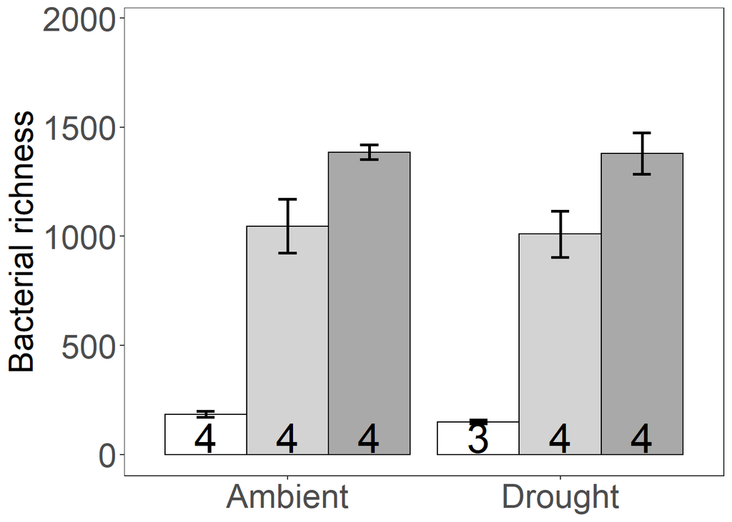

### Presence Richness

Diagnostic Graphs

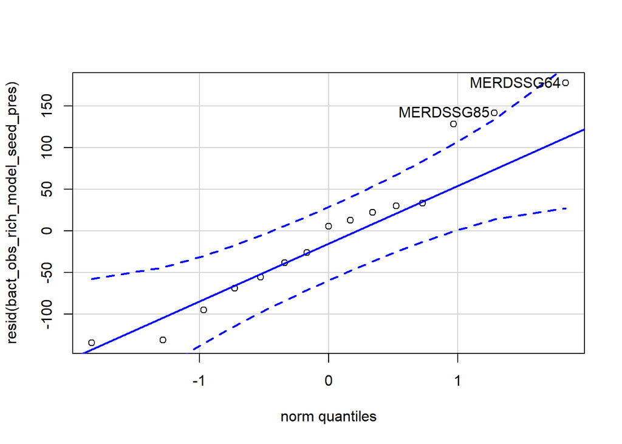

```
## MERDSSG64 MERDSSG85
##         8        14
```

```r
SILVA_MERDS_rar.divfil_pres_seed=subset(SILVA_MERDS_rar.divfil_trt_seed, root_association =="B")

bact_obs_rich_model_seed_pres= lmer((Observed)~soil_root*precip+(1|block), data= SILVA_MERDS_rar.divfil_pres_seed)
qqPlot(resid(bact_obs_rich_model_seed_pres))
```

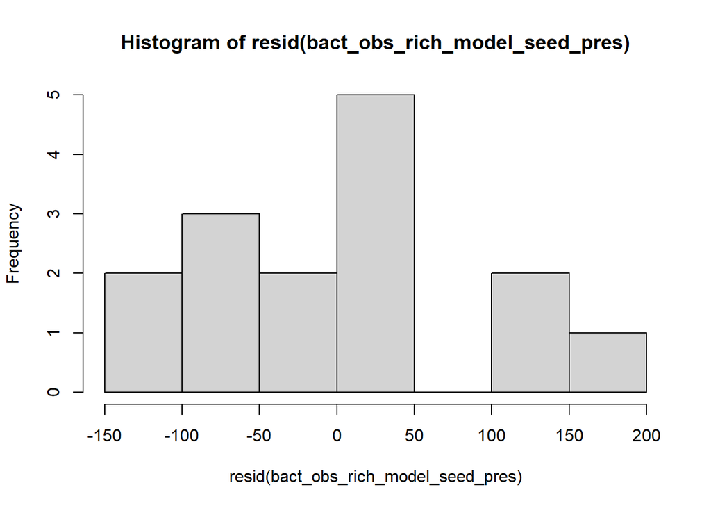

```r
hist(resid(bact_obs_rich_model_seed_pres))
```

```r
shapiro.test(resid(bact_obs_rich_model_seed_pres))
```

```
##
##  Shapiro-Wilk normality test
##
## data:  resid(bact_obs_rich_model_seed_pres)
## W = 0.94845, p-value = 0.5004
```

Raw Statistical output

```r
anova(bact_obs_rich_model_seed_pres)
```

```
## Type III Analysis of Variance Table with Satterthwaite's method
##                   Sum Sq Mean Sq NumDF  DenDF  F value    Pr(>F)
## soil_root        2552683 2552683     1 8.1575 175.6413 8.377e-07 ***
## precip              3934    3934     1 8.1575   0.2707    0.6167
## soil_root:precip      21      21     1 8.1575   0.0015    0.9704
## ---
## Signif. codes:  0 '***' 0.001 '**' 0.01 '*' 0.05 '.' 0.1 ' ' 1
```

```r
emmeans(bact_obs_rich_model_seed_pres, pairwise~soil_root|precip)
```

```
## Note: Use 'contrast(regrid(object), ...)' to obtain contrasts of back-transformed estimates
```

```
## $emmeans
## precip = A:
##  soil_root emmean    SE   df lower.CL upper.CL
##  L.B         1047  88.9 6.03    829.5     1264
##  S.B          184  88.9 6.03    -33.0      402
##
## precip = D:
##  soil_root emmean    SE   df lower.CL upper.CL
##  L.B         1010  88.9 6.03    793.2     1228
##  S.B          153 103.6 7.89    -86.6      393
##
## Degrees-of-freedom method: kenward-roger
## Results are given on the ( (not the response) scale.
## Confidence level used: 0.95
##
## $contrasts
## precip = A:
##  contrast  estimate    SE   df t.ratio p.value
##  L.B - S.B      862  85.2 8.00 10.118  <.0001
##
## precip = D:
##  contrast  estimate    SE   df t.ratio p.value
##  L.B - S.B      858 100.5 8.49  8.530  <.0001
##
## Note: contrasts are still on the ( scale
## Degrees-of-freedom method: kenward-roger
```

Formatted Anova table

Presence Seed soil communtiy richness

|  | Df | Resid.Df | F.value | P.value |
| --- | --- | --- | --- | --- |
| soil_root | 1 | 8.16 | 175.64 | 0.000 |
| precip | 1 | 8.16 | 0.27 | 0.617 |
| soil_root:precip | 1 | 8.16 | 0.00 | 0.970 |

### Origin Richness

Diagnostic Graphs

```r
SILVA_MERDS_rar.divfil_orig_seed=subset(SILVA_MERDS_rar.divfil_trt_seed, soil_status =="L")

bact_obs_rich_model_seed_orig= lmer((Observed)~soil_root*precip+(1|block), data= SILVA_MERDS_rar.divfil_orig_seed)
```

```
## boundary (singular) fit: see ?isSingular
```

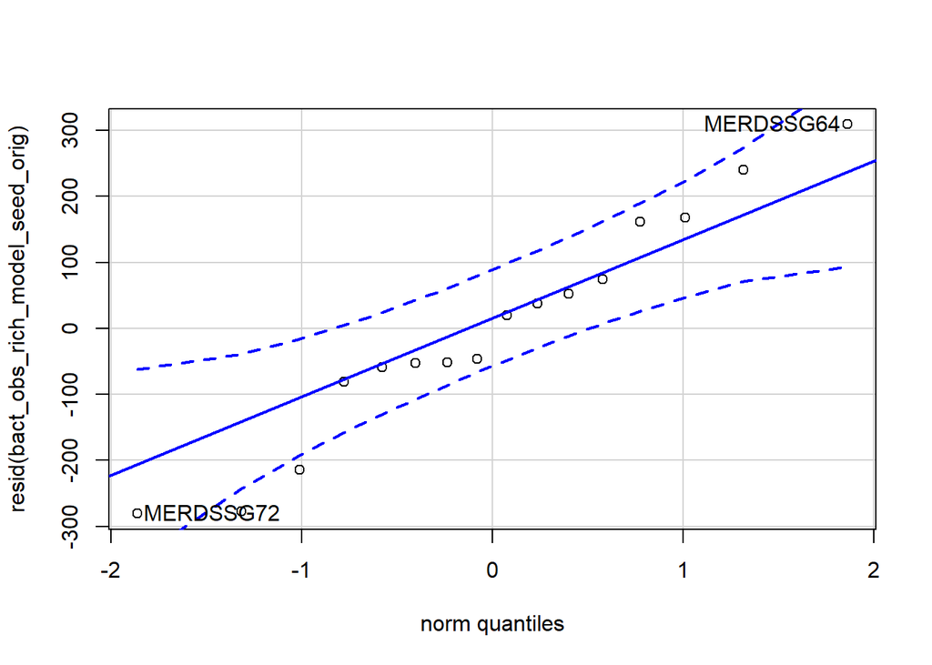

```
## MERDSSG64 MERDSSG72
##        13        15
```

```r
qqPlot(resid(bact_obs_rich_model_seed_orig))
```

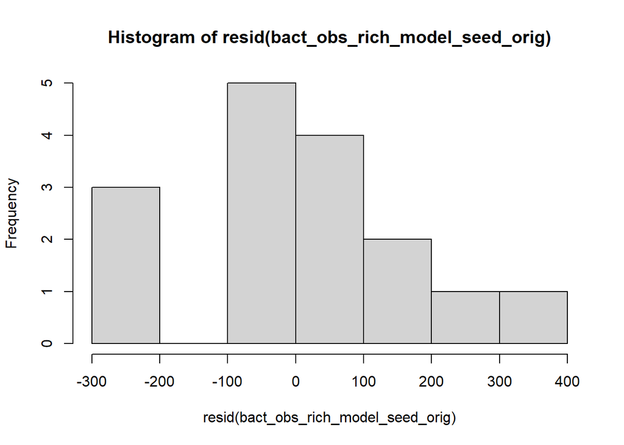

```r
hist(resid(bact_obs_rich_model_seed_orig))
```

```r
shapiro.test(resid(bact_obs_rich_model_seed_orig))
```

```
##
##  Shapiro-Wilk normality test
##
## data:  resid(bact_obs_rich_model_seed_orig)
## W = 0.96217, p-value = 0.7012
```

Raw Statistical output

```r
anova(bact_obs_rich_model_seed_orig)
```

```
## Type III Analysis of Variance Table with Satterthwaite's method
##                  Sum Sq Mean Sq NumDF DenDF F value  Pr(>F)
## soil_root        502327  502327     1    12 13.8057 0.00295 **
## precip             1785    1785     1    12  0.0491 0.82843
## soil_root:precip    915     915     1    12  0.0251 0.87663
## ---
## Signif. codes:  0 '***' 0.001 '**' 0.01 '*' 0.05 '.' 0.1 ' ' 1
```

```r
emmeans(bact_obs_rich_model_seed_orig, pairwise~soil_root|precip)
```

```
## Note: Use 'contrast(regrid(object), ...)' to obtain contrasts of back-transformed estimates
```

```
## $emmeans
## precip = A:
##  soil_root emmean    SE   df lower.CL upper.CL
##  L.B         1047  95.4 12.0      839     1255
##  L.R         1386  95.4 12.0     1178     1594
##
## precip = D:
##  soil_root emmean    SE   df lower.CL upper.CL
##  L.B         1010  95.4 12.0      803     1218
##  L.R         1380 104.7 10.9     1149     1611
##
## Degrees-of-freedom method: kenward-roger
## Results are given on the ( (not the response) scale.
## Confidence level used: 0.95
##
## $contrasts
## precip = A:
##  contrast  estimate  SE    df t.ratio p.value
##  L.B - L.R     -339 135  9.08 -2.515  0.0328
##
## precip = D:
##  contrast  estimate  SE    df t.ratio p.value
##  L.B - L.R     -370 142 10.20 -2.609  0.0257
##
## Note: contrasts are still on the ( scale
## Degrees-of-freedom method: kenward-roger
```

Formatted Anova table

|  | Df | Resid.Df | F.value | P.value |
| --- | --- | --- | --- | --- |
| soil_root | 1 | 12 | 13.81 | 0.003 |
| precip | 1 | 12 | 0.05 | 0.828 |
| soil_root:precip | 1 | 12 | 0.03 | 0.877 |

### Seed inv Simpson

Diagnostic Graphs

```r
bact_inv_simp_model_seed= lmer(log(InvSimpson)~soil_root*precip+(1|block), data= SILVA_MERDS_rar.divfil_trt_seed)
```

```
## boundary (singular) fit: see ?isSingular
```

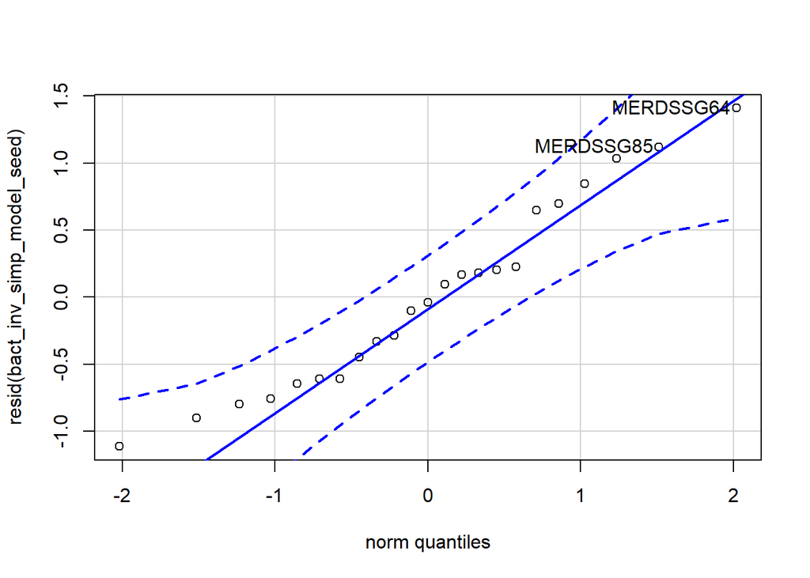

```
## MERDSSG64 MERDSSG85
##        16        22
```

```r
qqPlot(resid(bact_inv_simp_model_seed))
```

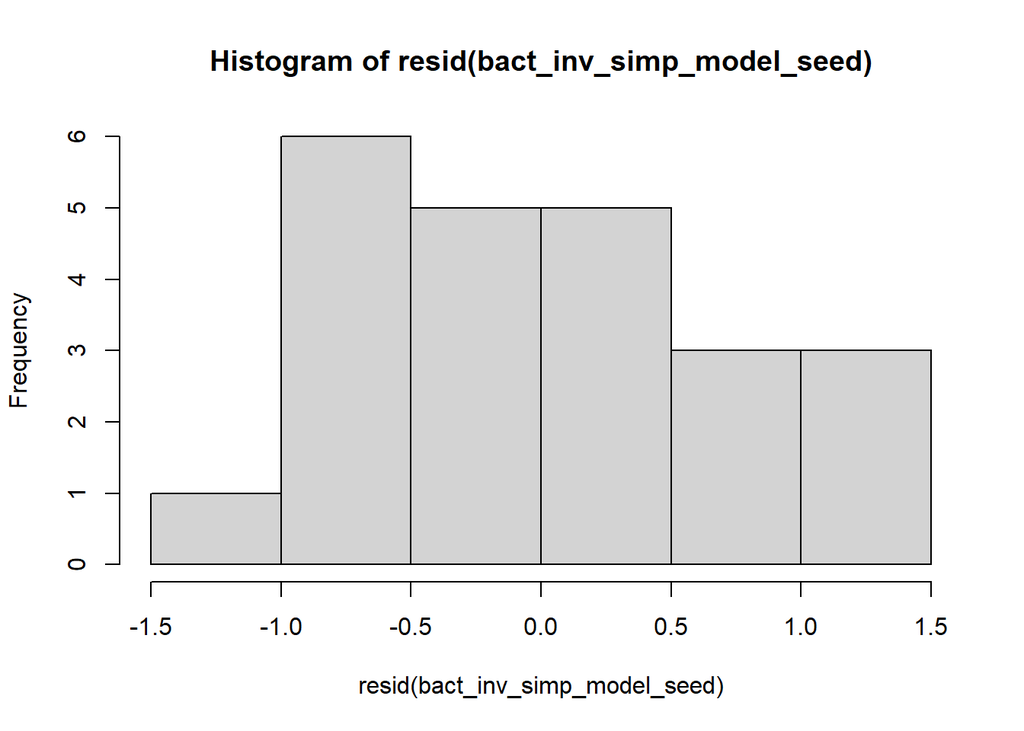

```r
hist(resid(bact_inv_simp_model_seed))
```

```r
shapiro.test(resid(bact_inv_simp_model_seed))
```

```
##
##  Shapiro-Wilk normality test
##
## data:  resid(bact_inv_simp_model_seed)
## W = 0.9605, p-value = 0.4735
```

Raw Statistical output

```r
anova(bact_inv_simp_model_seed)
```

```
## Type III Analysis of Variance Table with Satterthwaite's method
##                   Sum Sq Mean Sq NumDF DenDF F value    Pr(>F)
## soil_root        21.1667 10.5834     2    17 16.4729 0.0001051 ***
## precip            0.0194  0.0194     1    17  0.0301 0.8642430
## soil_root:precip  0.3080  0.1540     2    17  0.2397 0.7894614
## ---
## Signif. codes:  0 '***' 0.001 '**' 0.01 '*' 0.05 '.' 0.1 ' ' 1
```

```r
emmeans(bact_inv_simp_model_seed, pairwise~soil_root|precip)
```

```
## $emmeans
## precip = A:
##  soil_root emmean    SE   df lower.CL upper.CL
##  L.B         2.91 0.401 17.0     2.07     3.76
##  S.B         2.09 0.401 17.0     1.24     2.94
##  L.R         4.62 0.401 17.0     3.78     5.47
##
## precip = D:
##  soil_root emmean    SE   df lower.CL upper.CL
##  L.B         2.71 0.401 17.0     1.86     3.56
##  S.B         2.37 0.515 15.0     1.27     3.46
##  L.R         4.37 0.428 15.8     3.47     5.28
##
## Degrees-of-freedom method: kenward-roger
## Results are given on the log (not the response) scale.
## Confidence level used: 0.95
##
## $contrasts
## precip = A:
##  contrast  estimate    SE   df t.ratio p.value
##  L.B - S.B    0.824 0.567 14.0  1.453  0.3420
##  L.B - L.R   -1.711 0.567 14.0 -3.019  0.0234
##  S.B - L.R   -2.535 0.567 14.0 -4.472  0.0014
##
## precip = D:
##  contrast  estimate    SE   df t.ratio p.value
##  L.B - S.B    0.342 0.652 16.3  0.524  0.8607
##  L.B - L.R   -1.665 0.586 15.3 -2.841  0.0310
##  S.B - L.R   -2.007 0.710 16.4 -2.827  0.0303
##
## Degrees-of-freedom method: kenward-roger
## Results are given on the log (not the response) scale.
## P value adjustment: tukey method for comparing a family of 3 estimates
```

```r
emmeans(bact_inv_simp_model_seed, pairwise~soil_root)
```

```
## NOTE: Results may be misleading due to involvement in interactions
```

```
## $emmeans
##  soil_root emmean    SE   df lower.CL upper.CL
##  L.B         2.81 0.283 13.3     2.20     3.42
##  S.B         2.23 0.326 12.0     1.52     2.94
##  L.R         4.50 0.293 11.9     3.86     5.14
##
## Results are averaged over the levels of: precip
## Degrees-of-freedom method: kenward-roger
## Results are given on the log (not the response) scale.
## Confidence level used: 0.95
##
## $contrasts
##  contrast  estimate    SE   df t.ratio p.value
##  L.B - S.B    0.583 0.432 15.4  1.349  0.3908
##  L.B - L.R   -1.688 0.408 14.7 -4.141  0.0025
##  S.B - L.R   -2.271 0.454 16.8 -5.000  0.0003
##
## Results are averaged over the levels of: precip
## Degrees-of-freedom method: kenward-roger
## Results are given on the log (not the response) scale.
## P value adjustment: tukey method for comparing a family of 3 estimates
```

Formatted Anova table

Seed soil communtiy inv Simpson

|  | Df | Resid.Df | F.value | P.value |
| --- | --- | --- | --- | --- |
| soil_root | 2 | 17 | 16.47 | 0.000 |
| precip | 1 | 17 | 0.03 | 0.864 |
| soil_root:precip | 2 | 17 | 0.24 | 0.789 |

##### Graph for publication

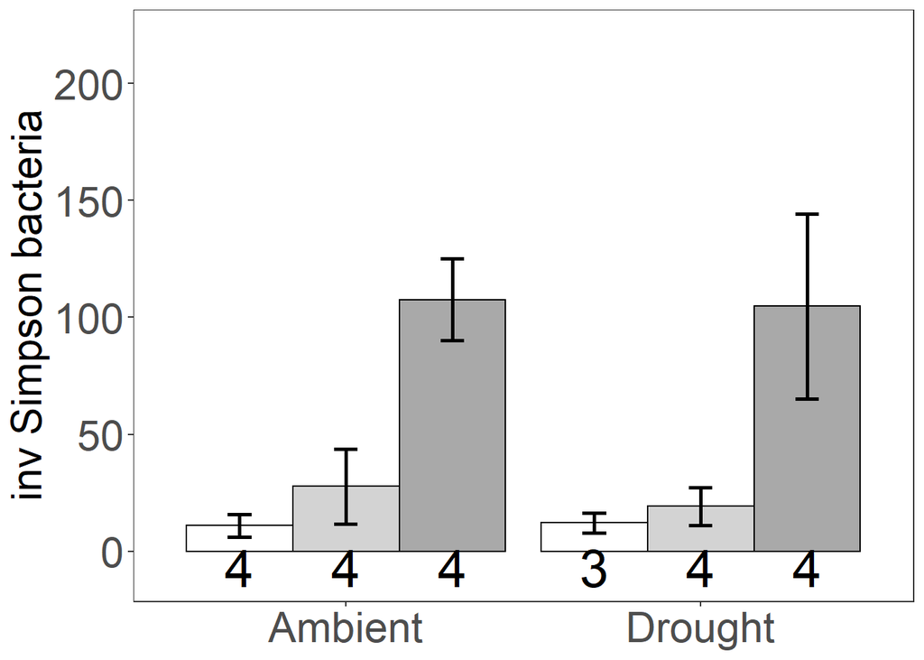

### Presence inv Simpson

Diagnostic Graphs

```r
SILVA_MERDS_rar.divfil_pres_seed=subset(SILVA_MERDS_rar.divfil_trt_seed, root_association =="B")

bact_inv_simp_model_seed_pres= lmer(log(InvSimpson)~soil_root*precip+(1|block), data= SILVA_MERDS_rar.divfil_pres_seed)
```

```
## boundary (singular) fit: see ?isSingular
```

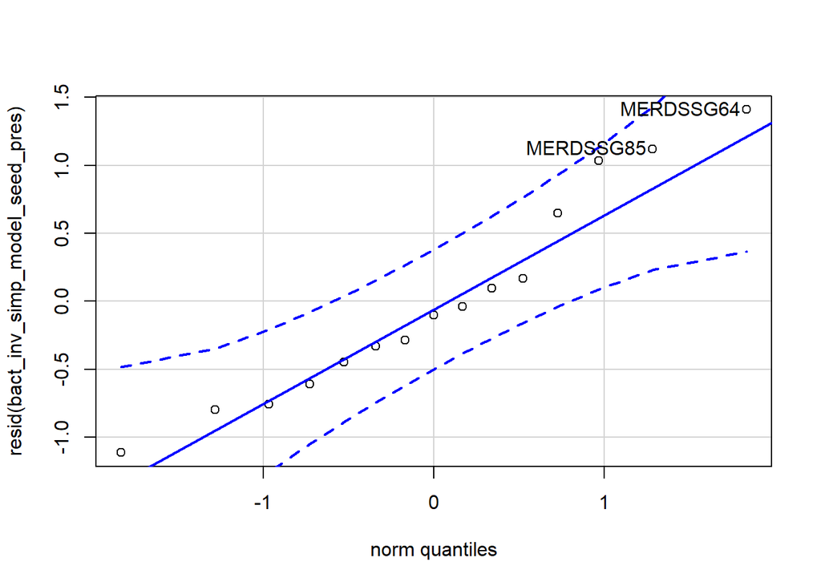

```
## MERDSSG64 MERDSSG85
##         8        14
```

```r
qqPlot(resid(bact_inv_simp_model_seed_pres))
```

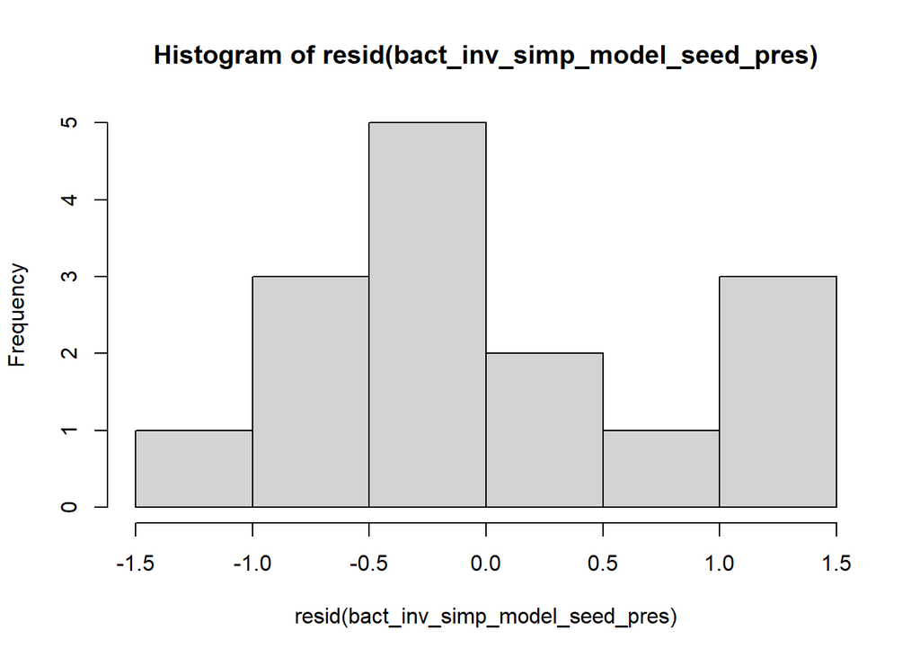

```r
hist(resid(bact_inv_simp_model_seed_pres))
```

```r
shapiro.test(resid(bact_inv_simp_model_seed_pres))
```

```
##
##  Shapiro-Wilk normality test
##
## data:  resid(bact_inv_simp_model_seed_pres)
## W = 0.94488, p-value = 0.4478
```

Raw Statistical output

```r
anova(bact_inv_simp_model_seed_pres)
```

```
## Type III Analysis of Variance Table with Satterthwaite's method
##                   Sum Sq Mean Sq NumDF DenDF F value Pr(>F)
## soil_root        1.25385 1.25385     1    11  1.7263 0.2156
## precip           0.00516 0.00516     1    11  0.0071 0.9343
## soil_root:precip 0.21415 0.21415     1    11  0.2948 0.5980
```

```r
emmeans(bact_inv_simp_model_seed_pres, pairwise~soil_root|precip)
```

```
## $emmeans
## precip = A:
##  soil_root emmean    SE    df lower.CL upper.CL
##  L.B         2.91 0.426 10.98     1.98     3.85
##  S.B         2.09 0.426 10.98     1.15     3.03
##
## precip = D:
##  soil_root emmean    SE    df lower.CL upper.CL
##  L.B         2.71 0.426 10.98     1.77     3.65
##  S.B         2.37 0.590  9.05     1.03     3.70
##
## Degrees-of-freedom method: kenward-roger
## Results are given on the log (not the response) scale.
## Confidence level used: 0.95
##
## $contrasts
## precip = A:
##  contrast  estimate    SE   df t.ratio p.value
##  L.B - S.B    0.824 0.603  8.1 1.367   0.2085
##
## precip = D:
##  contrast  estimate    SE   df t.ratio p.value
##  L.B - S.B    0.342 0.728 10.3 0.470   0.6484
##
## Degrees-of-freedom method: kenward-roger
## Results are given on the log (not the response) scale.
```

Formatted Anova table

Presence Seed soil communtiy inv Simpson

|  | Df | Resid.Df | F.value | P.value |
| --- | --- | --- | --- | --- |
| soil_root | 1 | 11 | 1.73 | 0.216 |
| precip | 1 | 11 | 0.01 | 0.934 |
| soil_root:precip | 1 | 11 | 0.29 | 0.598 |

### Origin inv Simpson

Diagnostic Graphs

```r
SILVA_MERDS_rar.divfil_orig_seed=subset(SILVA_MERDS_rar.divfil_trt_seed, soil_status =="L")

bact_inv_simp_model_seed_orig= lmer((InvSimpson)~soil_root*precip+(1|block), data= SILVA_MERDS_rar.divfil_orig_seed)
```

```
## boundary (singular) fit: see ?isSingular
```

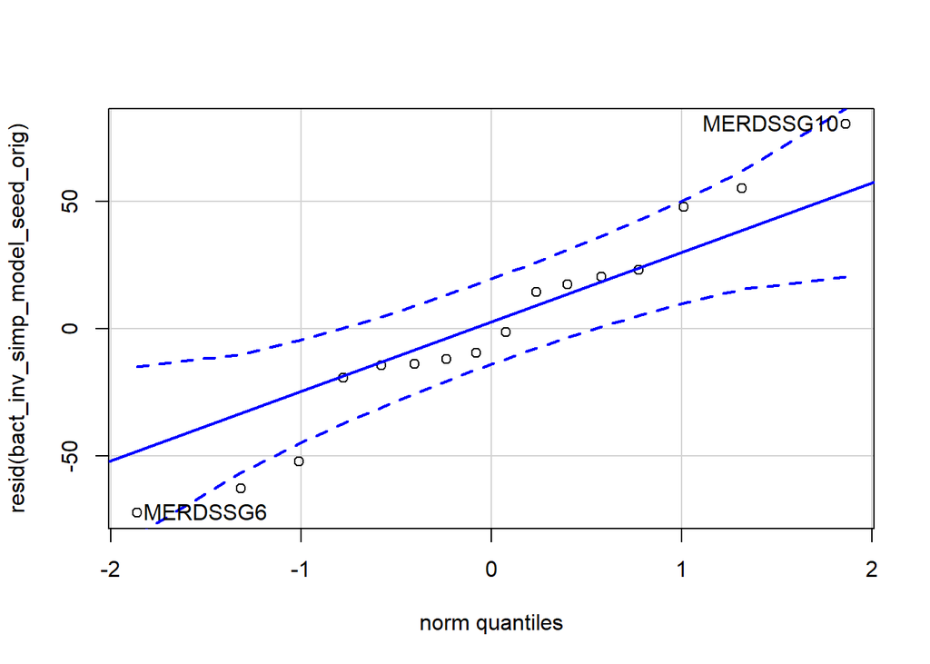

```
## MERDSSG10  MERDSSG6
##         1        12
```

```r
qqPlot(resid(bact_inv_simp_model_seed_orig))
```

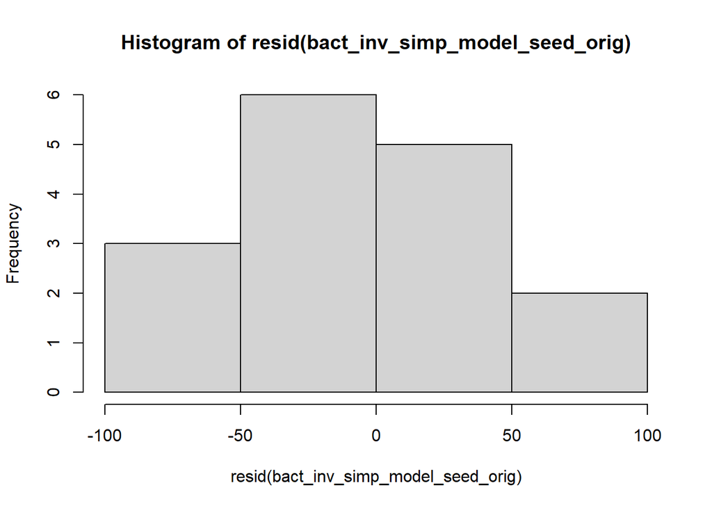

```r
hist(resid(bact_inv_simp_model_seed_orig))
```

```r
shapiro.test(resid(bact_inv_simp_model_seed_orig))
```

```
##
##  Shapiro-Wilk normality test
##
## data:  resid(bact_inv_simp_model_seed_orig)
## W = 0.97082, p-value = 0.8517
```

Raw Statistical output

```r
anova(bact_inv_simp_model_seed_orig)
```

```
## Type III Analysis of Variance Table with Satterthwaite's method
##                   Sum Sq Mean Sq NumDF DenDF F value  Pr(>F)
## soil_root        27358.3 27358.3     1    12 12.5228 0.00408 **
## precip             130.5   130.5     1    12  0.0597 0.81107
## soil_root:precip    32.0    32.0     1    12  0.0146 0.90569
## ---
## Signif. codes:  0 '***' 0.001 '**' 0.01 '*' 0.05 '.' 0.1 ' ' 1
```

```r
emmeans(bact_inv_simp_model_seed_orig, pairwise~soil_root|precip)
```

```
## Note: Use 'contrast(regrid(object), ...)' to obtain contrasts of back-transformed estimates
```

```
## $emmeans
## precip = A:
##  soil_root emmean   SE   df lower.CL upper.CL
##  L.B         27.7 23.4 12.0    -23.2     78.6
##  L.R        107.6 23.4 12.0     56.7    158.5
##
## precip = D:
##  soil_root emmean   SE   df lower.CL upper.CL
##  L.B         19.2 23.4 12.0    -31.7     70.1
##  L.R        104.7 25.6 10.9     48.2    161.2
##
## Degrees-of-freedom method: kenward-roger
## Results are given on the ( (not the response) scale.
## Confidence level used: 0.95
##
## $contrasts
## precip = A:
##  contrast  estimate   SE    df t.ratio p.value
##  L.B - L.R    -79.9 33.1  9.08 -2.417  0.0386
##
## precip = D:
##  contrast  estimate   SE    df t.ratio p.value
##  L.B - L.R    -85.5 34.7 10.20 -2.465  0.0330
##
## Note: contrasts are still on the ( scale
## Degrees-of-freedom method: kenward-roger
```

Formatted Anova table

|  | Df | Resid.Df | F.value | P.value |
| --- | --- | --- | --- | --- |
| soil_root | 1 | 12 | 12.52 | 0.004 |
| precip | 1 | 12 | 0.06 | 0.811 |
| soil_root:precip | 1 | 12 | 0.01 | 0.906 |

## Diversity across the life stages

### Combined Richness

Diagnostic Graphs

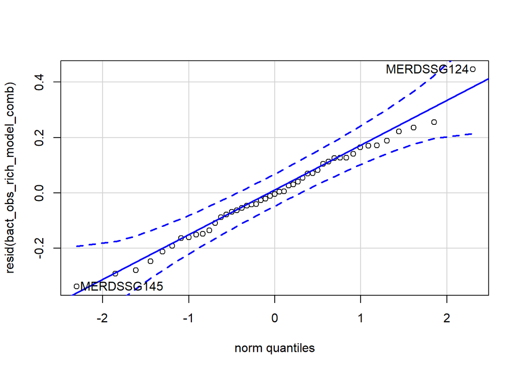

```
## MERDSSG124 MERDSSG145
##          8         15
```

```r
bact_obs_rich_model_comb= lmer(log(Observed)~soil_root*precip*life_stage+(1|block), data= SILVA_MERDS_rar.divfil_trt)
qqPlot(resid(bact_obs_rich_model_comb))
```

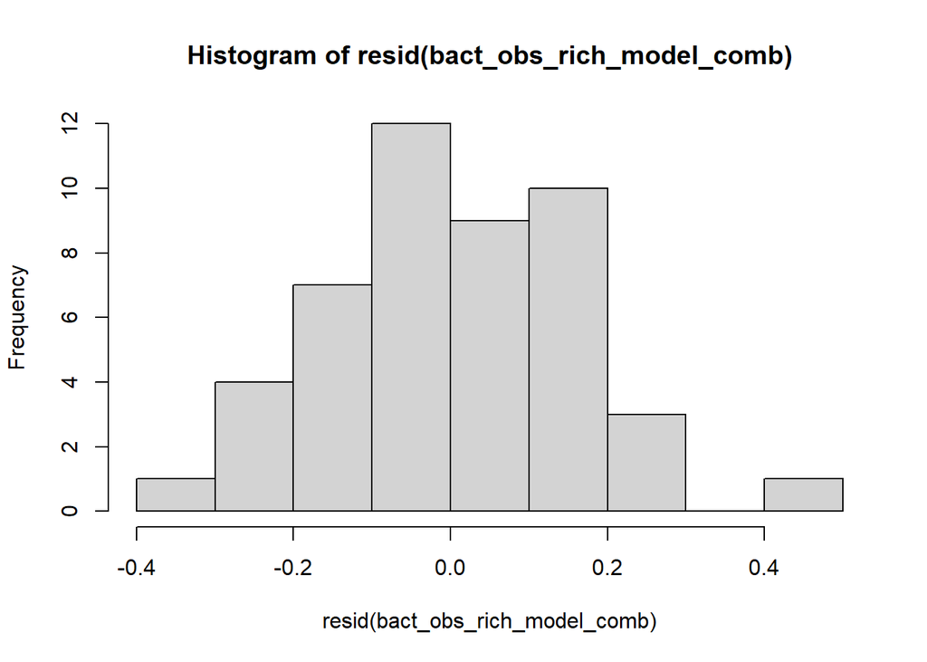

```r
hist(resid(bact_obs_rich_model_comb))
```

```r
shapiro.test(resid(bact_obs_rich_model_comb))
```

```
##
##  Shapiro-Wilk normality test
##
## data:  resid(bact_obs_rich_model_comb)
## W = 0.99017, p-value = 0.9593
```

Raw Statistical output

```r
anova(bact_obs_rich_model_comb)
```

```
## Type III Analysis of Variance Table with Satterthwaite's method
##                             Sum Sq Mean Sq NumDF  DenDF  F value  Pr(>F)
## soil_root                   35.332 17.6660     2 32.690 509.2191 < 2e-16 ***
## precip                       0.260  0.2599     1 32.106   7.4926 0.01002 *
## life_stage                   0.246  0.2462     1 32.106   7.0961 0.01198 *
## soil_root:precip             0.060  0.0301     2 32.690   0.8683 0.42910
## soil_root:life_stage         0.315  0.1573     2 32.690   4.5331 0.01830 *
## precip:life_stage            0.052  0.0516     1 32.106   1.4876 0.23147
## soil_root:precip:life_stage  0.054  0.0271     2 32.690   0.7806 0.46647
## ---
## Signif. codes:  0 '***' 0.001 '**' 0.01 '*' 0.05 '.' 0.1 ' ' 1
```

```r
emmeans(bact_obs_rich_model_comb, pairwise~soil_root|life_stage)
```

```
## NOTE: Results may be misleading due to involvement in interactions
```

```
## $emmeans
## life_stage = G:
##  soil_root emmean     SE   df lower.CL upper.CL
##  L.B         7.18 0.0680 27.8     7.04     7.32
##  S.B         5.37 0.0680 27.8     5.23     5.51
##  L.R         7.14 0.0680 27.8     7.00     7.28
##
## life_stage = S:
##  soil_root emmean     SE   df lower.CL upper.CL
##  L.B         6.92 0.0680 27.8     6.78     7.06
##  S.B         5.11 0.0752 27.8     4.96     5.26
##  L.R         7.22 0.0689 26.6     7.08     7.36
##
## Results are averaged over the levels of: precip
## Degrees-of-freedom method: kenward-roger
## Results are given on the log (not the response) scale.
## Confidence level used: 0.95
##
## $contrasts
## life_stage = G:
##  contrast  estimate     SE   df t.ratio p.value
##  L.B - S.B   1.8081 0.0931 32.0  19.415 <.0001
##  L.B - L.R   0.0405 0.0931 32.0   0.435 0.9012
##  S.B - L.R  -1.7675 0.0931 32.0 -18.979 <.0001
##
## life_stage = S:
##  contrast  estimate     SE   df t.ratio p.value
##  L.B - S.B   1.8061 0.0985 33.1  18.332 <.0001
##  L.B - L.R  -0.3071 0.0938 32.5  -3.273 0.0069
##  S.B - L.R  -2.1132 0.1009 34.3 -20.951 <.0001
##
## Results are averaged over the levels of: precip
## Degrees-of-freedom method: kenward-roger
## Results are given on the log (not the response) scale.
## P value adjustment: tukey method for comparing a family of 3 estimates
```

```r
emmeans(bact_obs_rich_model_comb, pairwise~life_stage|soil_root)
```

```
## NOTE: Results may be misleading due to involvement in interactions
```

```
## $emmeans
## soil_root = L.B:
##  life_stage emmean     SE   df lower.CL upper.CL
##  G            7.18 0.0680 27.8     7.04     7.32
##  S            6.92 0.0680 27.8     6.78     7.06
##
## soil_root = S.B:
##  life_stage emmean     SE   df lower.CL upper.CL
##  G            5.37 0.0680 27.8     5.23     5.51
##  S            5.11 0.0752 27.8     4.96     5.26
##
## soil_root = L.R:
##  life_stage emmean     SE   df lower.CL upper.CL
##  G            7.14 0.0680 27.8     7.00     7.28
##  S            7.22 0.0689 26.6     7.08     7.36
##
## Results are averaged over the levels of: precip
## Degrees-of-freedom method: kenward-roger
## Results are given on the log (not the response) scale.
## Confidence level used: 0.95
##
## $contrasts
## soil_root = L.B:
##  contrast estimate     SE   df t.ratio p.value
##  G - S      0.2618 0.0931 32.0  2.811  0.0084
##
## soil_root = S.B:
##  contrast estimate     SE   df t.ratio p.value
##  G - S      0.2599 0.0985 33.1  2.638  0.0126
##
## soil_root = L.R:
##  contrast estimate     SE   df t.ratio p.value
##  G - S     -0.0858 0.0938 32.5 -0.915  0.3669
##
## Results are averaged over the levels of: precip
## Degrees-of-freedom method: kenward-roger
## Results are given on the log (not the response) scale.
```

Formatted Anova table

Combined soil communtiy richness

|  | Df | Resid.Df | F.value | P.value |
| --- | --- | --- | --- | --- |
| soil_root | 2 | 32.69 | 509.22 | 0.000 |
| precip | 1 | 32.11 | 7.49 | 0.010 |
| life_stage | 1 | 32.11 | 7.10 | 0.012 |
| soil_root:precip | 2 | 32.69 | 0.87 | 0.429 |
| soil_root:life_stage | 2 | 32.69 | 4.53 | 0.018 |
| precip:life_stage | 1 | 32.11 | 1.49 | 0.231 |
| soil_root:precip:life_stage | 2 | 32.69 | 0.78 | 0.466 |

### Presence Richness

Diagnostic Graphs

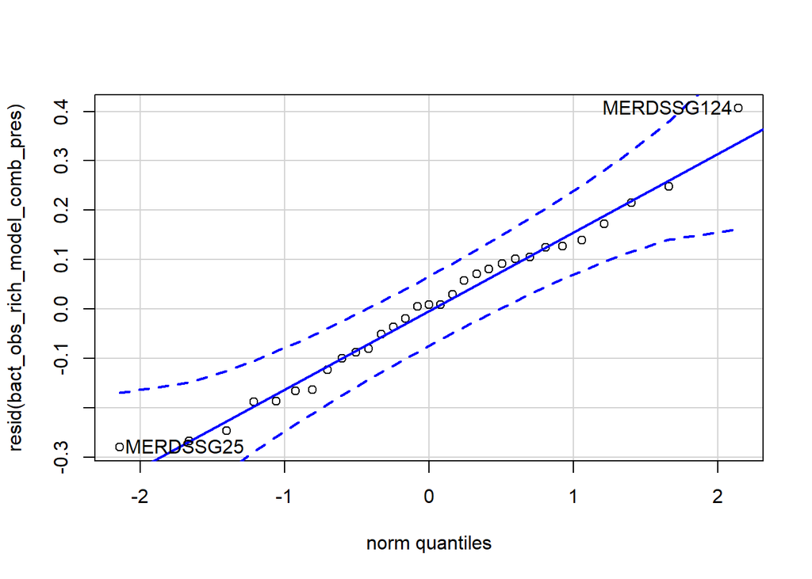

```
## MERDSSG124  MERDSSG25
##          5         19
```

```r
SILVA_MERDS_rar.divfil_pres_comb=subset(SILVA_MERDS_rar.divfil_trt, root_association =="B")

bact_obs_rich_model_comb_pres= lmer(log(Observed)~soil_root*precip*life_stage+(1|block), data= SILVA_MERDS_rar.divfil_pres_comb)
qqPlot(resid(bact_obs_rich_model_comb_pres))
```

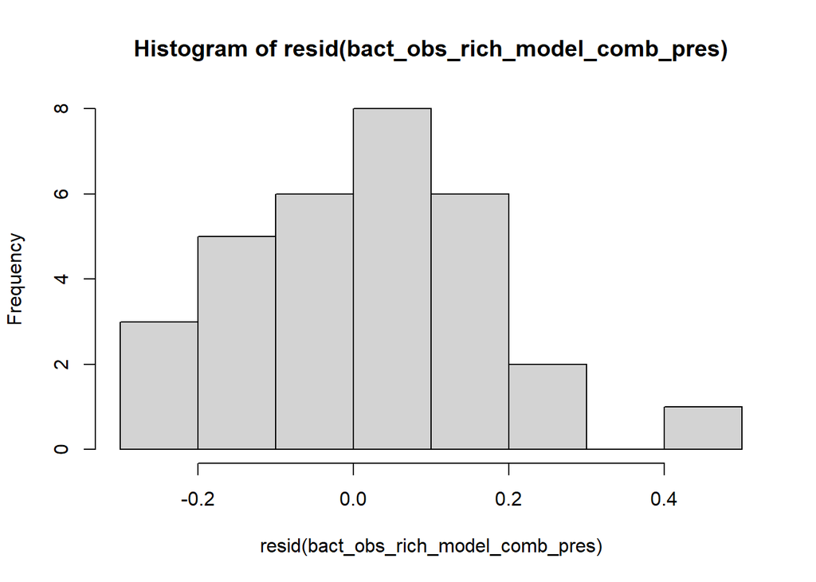

```r
hist(resid(bact_obs_rich_model_comb_pres))
```

```r
shapiro.test(resid(bact_obs_rich_model_comb_pres))
```

```
##
##  Shapiro-Wilk normality test
##
## data:  resid(bact_obs_rich_model_comb_pres)
## W = 0.9803, p-value = 0.8209
```

Raw Statistical output

```r
anova(bact_obs_rich_model_comb_pres)
```

```
## Type III Analysis of Variance Table with Satterthwaite's method
##                              Sum Sq Mean Sq NumDF  DenDF  F value    Pr(>F)
## soil_root                   24.7191 24.7191     1 20.297 685.0705 < 2.2e-16 ***
## precip                       0.1250  0.1250     1 20.297   3.4652  0.077218 .
## life_stage                   0.4998  0.4998     1 20.297  13.8510  0.001321 **
## soil_root:precip             0.0469  0.0469     1 20.297   1.2994  0.267590
## soil_root:life_stage         0.0002  0.0002     1 20.297   0.0063  0.937615
## precip:life_stage            0.0040  0.0040     1 20.297   0.1122  0.741128
## soil_root:precip:life_stage  0.0002  0.0002     1 20.297   0.0059  0.939416
## ---
## Signif. codes:  0 '***' 0.001 '**' 0.01 '*' 0.05 '.' 0.1 ' ' 1
```

Formatted Anova table

Presence Combined soil communtiy richness

|  | Df | Resid.Df | F.value | P.value |
| --- | --- | --- | --- | --- |
| soil_root | 1 | 20.3 | 685.07 | 0.000 |
| precip | 1 | 20.3 | 3.47 | 0.077 |
| life_stage | 1 | 20.3 | 13.85 | 0.001 |
| soil_root:precip | 1 | 20.3 | 1.30 | 0.268 |
| soil_root:life_stage | 1 | 20.3 | 0.01 | 0.938 |
| precip:life_stage | 1 | 20.3 | 0.11 | 0.741 |
| soil_root:precip:life_stage | 1 | 20.3 | 0.01 | 0.939 |

### Origin Richness

Diagnostic Graphs

```r
SILVA_MERDS_rar.divfil_orig_comb=subset(SILVA_MERDS_rar.divfil_trt, soil_status =="L")

bact_obs_rich_model_comb_orig= lmer((Observed)~soil_root*precip*life_stage+(1|block), data= SILVA_MERDS_rar.divfil_orig_comb)
```

```
## boundary (singular) fit: see ?isSingular
```

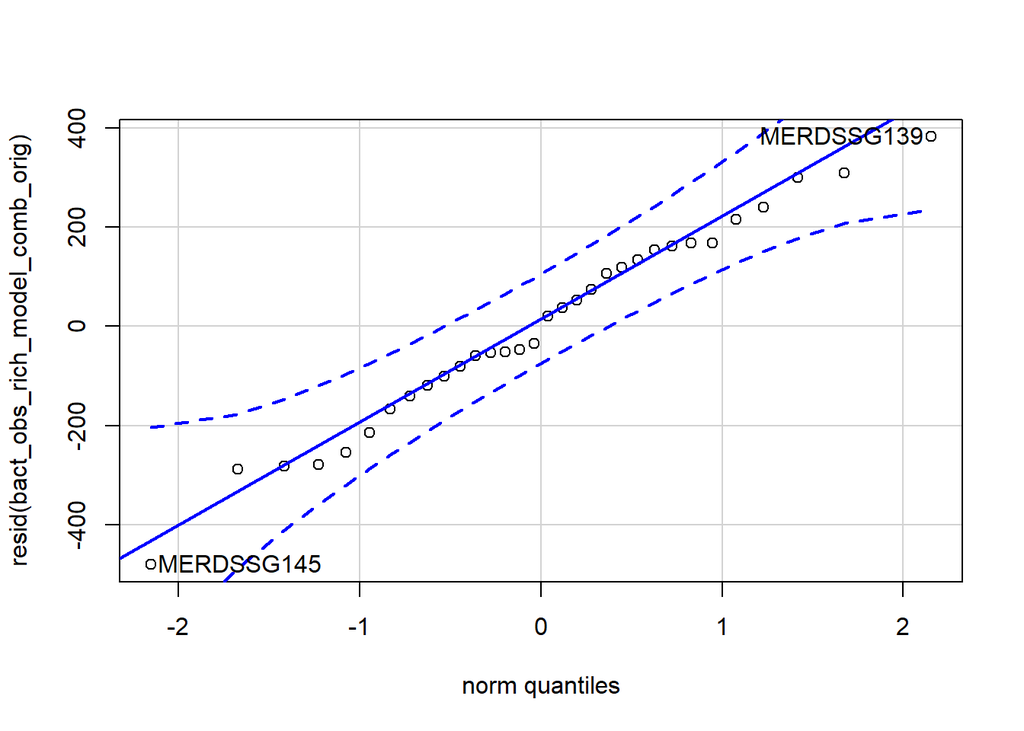

```
## MERDSSG145 MERDSSG139
##         11          8
```

```r
qqPlot(resid(bact_obs_rich_model_comb_orig))
```

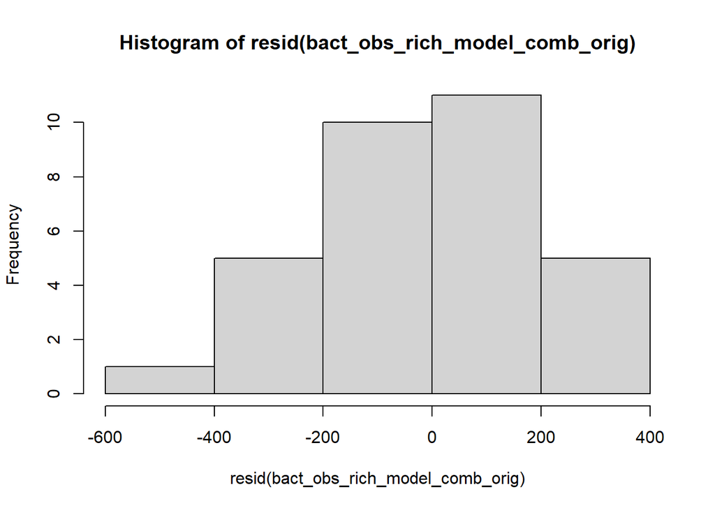

```r
hist(resid(bact_obs_rich_model_comb_orig))
```

```r
shapiro.test(resid(bact_obs_rich_model_comb_orig))
```

```
##
##  Shapiro-Wilk normality test
##
## data:  resid(bact_obs_rich_model_comb_orig)
## W = 0.98421, p-value = 0.9085
```

Raw Statistical output

```r
anova(bact_obs_rich_model_comb_orig)
```

```
## Type III Analysis of Variance Table with Satterthwaite's method
##                             Sum Sq Mean Sq NumDF DenDF F value  Pr(>F)
## soil_root                   213695  213695     1    24  4.0578 0.05530 .
## precip                      175380  175380     1    24  3.3303 0.08049 .
## life_stage                   92558   92558     1    24  1.7576 0.19741
## soil_root:precip             62747   62747     1    24  1.1915 0.28587
## soil_root:life_stage        291657  291657     1    24  5.5383 0.02713 *
## precip:life_stage           128905  128905     1    24  2.4478 0.13078
## soil_root:precip:life_stage  86009   86009     1    24  1.6332 0.21348
## ---
## Signif. codes:  0 '***' 0.001 '**' 0.01 '*' 0.05 '.' 0.1 ' ' 1
```

```r
emmeans(bact_obs_rich_model_comb_orig, pairwise~soil_root|life_stage)
```

```
## NOTE: Results may be misleading due to involvement in interactions
```

```
## Note: Use 'contrast(regrid(object), ...)' to obtain contrasts of back-transformed estimates
```

```
## $emmeans
## life_stage = G:
##  soil_root emmean   SE   df lower.CL upper.CL
##  L.B         1327 81.1 20.8     1158     1496
##  L.R         1300 81.1 20.8     1131     1468
##
## life_stage = S:
##  soil_root emmean   SE   df lower.CL upper.CL
##  L.B         1029 81.1 20.8      860     1197
##  L.R         1383 83.0 19.4     1210     1556
##
## Results are averaged over the levels of: precip
## Degrees-of-freedom method: kenward-roger
## Results are given on the ( (not the response) scale.
## Confidence level used: 0.95
##
## $contrasts
## life_stage = G:
##  contrast  estimate  SE   df t.ratio p.value
##  L.B - L.R     27.5 115 21.0  0.240  0.8129
##
## life_stage = S:
##  contrast  estimate  SE   df t.ratio p.value
##  L.B - L.R   -354.4 116 21.7 -3.053  0.0059
##
## Results are averaged over the levels of: precip
## Note: contrasts are still on the ( scale
## Degrees-of-freedom method: kenward-roger
```

```r
emmeans(bact_obs_rich_model_comb_orig, pairwise~life_stage|soil_root)
```

```
## NOTE: Results may be misleading due to involvement in interactions
## Note: Use 'contrast(regrid(object), ...)' to obtain contrasts of back-transformed estimates
```

```
## $emmeans
## soil_root = L.B:
##  life_stage emmean   SE   df lower.CL upper.CL
##  G            1327 81.1 20.8     1158     1496
##  S            1029 81.1 20.8      860     1197
##
## soil_root = L.R:
##  life_stage emmean   SE   df lower.CL upper.CL
##  G            1300 81.1 20.8     1131     1468
##  S            1383 83.0 19.4     1210     1556
##
## Results are averaged over the levels of: precip
## Degrees-of-freedom method: kenward-roger
## Results are given on the ( (not the response) scale.
## Confidence level used: 0.95
##
## $contrasts
## soil_root = L.B:
##  contrast estimate  SE   df t.ratio p.value
##  G - S       298.5 115 21.0  2.602  0.0167
##
## soil_root = L.R:
##  contrast estimate  SE   df t.ratio p.value
##  G - S       -83.4 116 21.7 -0.718  0.4802
##
## Results are averaged over the levels of: precip
## Note: contrasts are still on the ( scale
## Degrees-of-freedom method: kenward-roger
```

Formatted Anova table

|  | Df | Resid.Df | F.value | P.value |
| --- | --- | --- | --- | --- |
| soil_root | 1 | 24 | 4.06 | 0.055 |
| precip | 1 | 24 | 3.33 | 0.080 |
| life_stage | 1 | 24 | 1.76 | 0.197 |
| soil_root:precip | 1 | 24 | 1.19 | 0.286 |
| soil_root:life_stage | 1 | 24 | 5.54 | 0.027 |
| precip:life_stage | 1 | 24 | 2.45 | 0.131 |
| soil_root:precip:life_stage | 1 | 24 | 1.63 | 0.213 |

### Combined inv Simpson

Diagnostic Graphs

```r
bact_inv_simp_model_comb= lmer(log(InvSimpson)~soil_root*precip*life_stage+(1|block), data= SILVA_MERDS_rar.divfil_trt)
```

```
## boundary (singular) fit: see ?isSingular
```

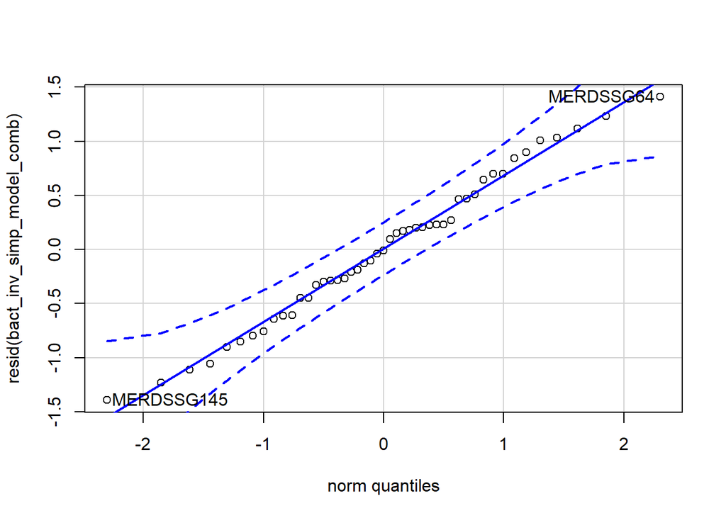

```
##  MERDSSG64 MERDSSG145
##         38         15
```

```r
qqPlot(resid(bact_inv_simp_model_comb))
```

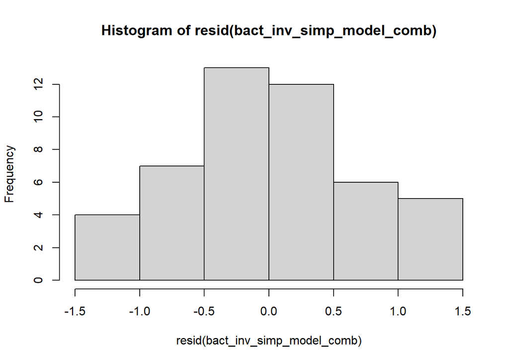

```r
hist(resid(bact_inv_simp_model_comb))
```

```r
shapiro.test(resid(bact_inv_simp_model_comb))
```

```
##
##  Shapiro-Wilk normality test
##
## data:  resid(bact_inv_simp_model_comb)
## W = 0.98673, p-value = 0.8654
```

Raw Statistical output

```r
anova(bact_inv_simp_model_comb)
```

```
## Type III Analysis of Variance Table with Satterthwaite's method
##                              Sum Sq Mean Sq NumDF DenDF F value    Pr(>F)
## soil_root                   23.2852 11.6426     2    35 18.9361 2.669e-06 ***
## precip                       1.0949  1.0949     1    35  1.7809   0.19066
## life_stage                   1.3884  1.3884     1    35  2.2582   0.14188
## soil_root:precip             1.2519  0.6260     2    35  1.0181   0.37174
## soil_root:life_stage         6.3974  3.1987     2    35  5.2025   0.01052 *
## precip:life_stage            0.7174  0.7174     1    35  1.1668   0.28745
## soil_root:precip:life_stage  1.2213  0.6107     2    35  0.9932   0.38059
## ---
## Signif. codes:  0 '***' 0.001 '**' 0.01 '*' 0.05 '.' 0.1 ' ' 1
```

```r
emmeans(bact_inv_simp_model_comb, pairwise~soil_root|life_stage)
```

```
## NOTE: Results may be misleading due to involvement in interactions
```

```
## $emmeans
## life_stage = G:
##  soil_root emmean    SE   df lower.CL upper.CL
##  L.B         3.99 0.277 31.6     3.42     4.55
##  S.B         2.69 0.277 31.6     2.12     3.25
##  L.R         3.90 0.277 31.6     3.33     4.46
##
## life_stage = S:
##  soil_root emmean    SE   df lower.CL upper.CL
##  L.B         2.81 0.277 31.6     2.25     3.38
##  S.B         2.23 0.309 30.1     1.60     2.86
##  L.R         4.50 0.281 30.1     3.92     5.07
##
## Results are averaged over the levels of: precip
## Degrees-of-freedom method: kenward-roger
## Results are given on the log (not the response) scale.
## Confidence level used: 0.95
##
## $contrasts
## life_stage = G:
##  contrast  estimate    SE   df t.ratio p.value
##  L.B - S.B   1.3010 0.392 32.0  3.318  0.0062
##  L.B - L.R   0.0902 0.392 32.0  0.230  0.9712
##  S.B - L.R  -1.2108 0.392 32.0 -3.088  0.0112
##
## life_stage = S:
##  contrast  estimate    SE   df t.ratio p.value
##  L.B - S.B   0.5827 0.415 33.4  1.404  0.3501
##  L.B - L.R  -1.6879 0.395 32.7 -4.272  0.0004
##  S.B - L.R  -2.2707 0.425 34.8 -5.341  <.0001
##
## Results are averaged over the levels of: precip
## Degrees-of-freedom method: kenward-roger
## Results are given on the log (not the response) scale.
## P value adjustment: tukey method for comparing a family of 3 estimates
```

```r
emmeans(bact_inv_simp_model_comb, pairwise~life_stage|soil_root)
```

```
## NOTE: Results may be misleading due to involvement in interactions
```

```
## $emmeans
## soil_root = L.B:
##  life_stage emmean    SE   df lower.CL upper.CL
##  G            3.99 0.277 31.6     3.42     4.55
##  S            2.81 0.277 31.6     2.25     3.38
##
## soil_root = S.B:
##  life_stage emmean    SE   df lower.CL upper.CL
##  G            2.69 0.277 31.6     2.12     3.25
##  S            2.23 0.309 30.1     1.60     2.86
##
## soil_root = L.R:
##  life_stage emmean    SE   df lower.CL upper.CL
##  G            3.90 0.277 31.6     3.33     4.46
##  S            4.50 0.281 30.1     3.92     5.07
##
## Results are averaged over the levels of: precip
## Degrees-of-freedom method: kenward-roger
## Results are given on the log (not the response) scale.
## Confidence level used: 0.95
##
## $contrasts
## soil_root = L.B:
##  contrast estimate    SE   df t.ratio p.value
##  G - S       1.177 0.392 32.0  3.002  0.0052
##
## soil_root = S.B:
##  contrast estimate    SE   df t.ratio p.value
##  G - S       0.459 0.415 33.4  1.106  0.2768
##
## soil_root = L.R:
##  contrast estimate    SE   df t.ratio p.value
##  G - S      -0.601 0.395 32.7 -1.522  0.1377
##
## Results are averaged over the levels of: precip
## Degrees-of-freedom method: kenward-roger
## Results are given on the log (not the response) scale.
```

Formatted Anova table

Combined soil communtiy inv Simpson

|  | Df | Resid.Df | F.value | P.value |
| --- | --- | --- | --- | --- |
| soil_root | 2 | 35 | 18.94 | 0.000 |
| precip | 1 | 35 | 1.78 | 0.191 |
| life_stage | 1 | 35 | 2.26 | 0.142 |
| soil_root:precip | 2 | 35 | 1.02 | 0.372 |
| soil_root:life_stage | 2 | 35 | 5.20 | 0.011 |
| precip:life_stage | 1 | 35 | 1.17 | 0.287 |
| soil_root:precip:life_stage | 2 | 35 | 0.99 | 0.381 |

### Presence inv Simpson

Diagnostic Graphs

```r
SILVA_MERDS_rar.divfil_pres_comb=subset(SILVA_MERDS_rar.divfil_trt, root_association =="B")

bact_inv_simp_model_comb_pres= lmer(log(InvSimpson)~soil_root*precip*life_stage+(1|block), data= SILVA_MERDS_rar.divfil_pres_comb)
```

```
## boundary (singular) fit: see ?isSingular
```

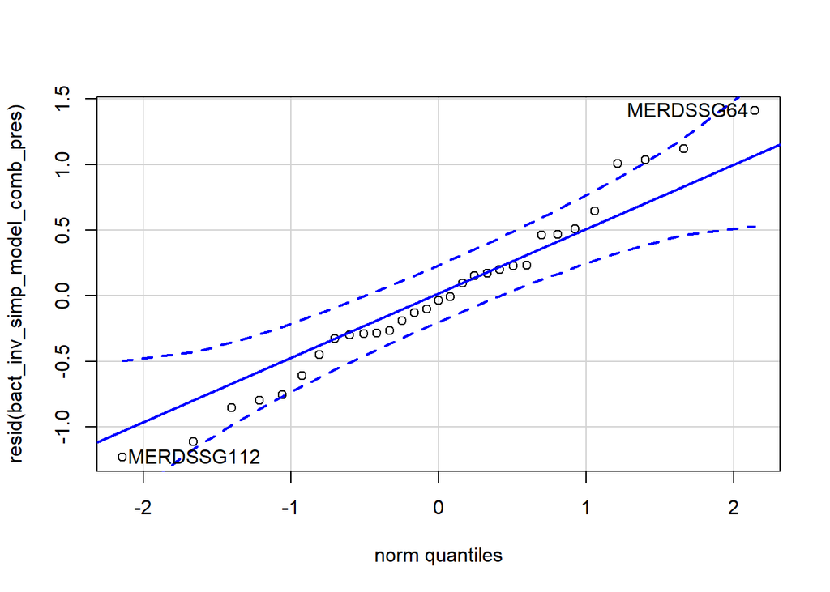

```
##  MERDSSG64 MERDSSG112
##         24          2
```

```r
qqPlot(resid(bact_inv_simp_model_comb_pres))
```

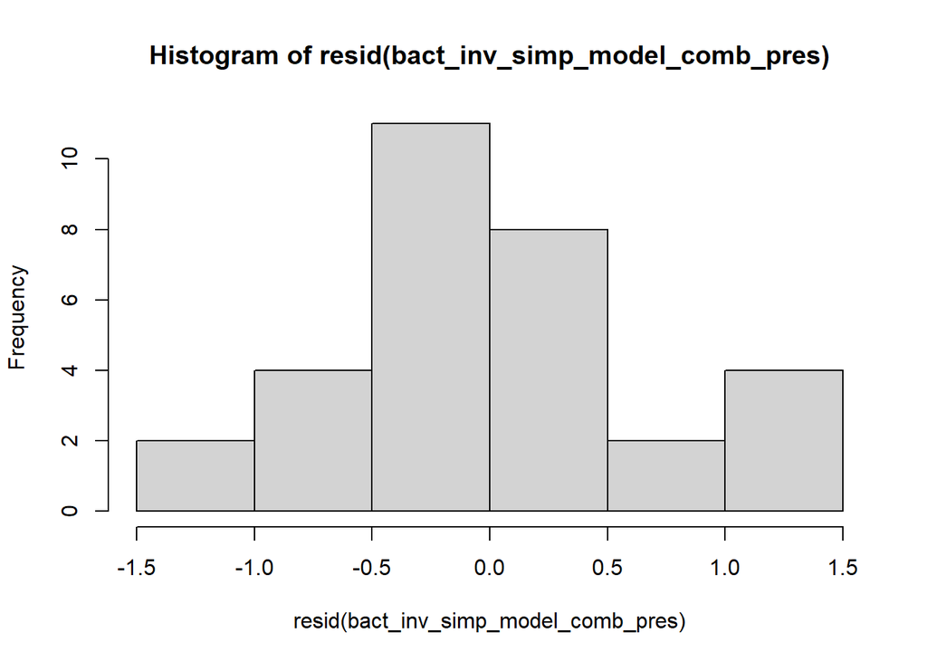

```r
hist(resid(bact_inv_simp_model_comb_pres))
```

```r
shapiro.test(resid(bact_inv_simp_model_comb_pres))
```

```
##
##  Shapiro-Wilk normality test
##
## data:  resid(bact_inv_simp_model_comb_pres)
## W = 0.9812, p-value = 0.8451
```

Raw Statistical output

```r
anova(bact_inv_simp_model_comb_pres)
```

```
## Type III Analysis of Variance Table with Satterthwaite's method
##                             Sum Sq Mean Sq NumDF DenDF F value   Pr(>F)
## soil_root                   6.8130  6.8130     1    23 12.6310 0.001690 **
## precip                      0.0521  0.0521     1    23  0.0966 0.758782
## life_stage                  5.1370  5.1370     1    23  9.5238 0.005217 **
## soil_root:precip            0.0530  0.0530     1    23  0.0983 0.756683
## soil_root:life_stage        0.9905  0.9905     1    23  1.8363 0.188543
## precip:life_stage           0.1101  0.1101     1    23  0.2042 0.655601
## soil_root:precip:life_stage 0.8058  0.8058     1    23  1.4940 0.233975
## ---
## Signif. codes:  0 '***' 0.001 '**' 0.01 '*' 0.05 '.' 0.1 ' ' 1
```

```r
emmeans(bact_inv_simp_model_comb_pres, pairwise~soil_root|precip)
```

```
## NOTE: Results may be misleading due to involvement in interactions
```

```
## $emmeans
## precip = A:
##  soil_root emmean    SE   df lower.CL upper.CL
##  L.B         3.40 0.260 19.7     2.86     3.94
##  S.B         2.54 0.260 19.7     2.00     3.08
##
## precip = D:
##  soil_root emmean    SE   df lower.CL upper.CL
##  L.B         3.40 0.260 19.7     2.86     3.94
##  S.B         2.38 0.295 18.4     1.76     2.99
##
## Results are averaged over the levels of: life_stage
## Degrees-of-freedom method: kenward-roger
## Results are given on the log (not the response) scale.
## Confidence level used: 0.95
##
## $contrasts
## precip = A:
##  contrast  estimate    SE   df t.ratio p.value
##  L.B - S.B    0.859 0.367 20.0 2.339   0.0298
##
## precip = D:
##  contrast  estimate    SE   df t.ratio p.value
##  L.B - S.B    1.025 0.393 21.4 2.610   0.0162
##
## Results are averaged over the levels of: life_stage
## Degrees-of-freedom method: kenward-roger
## Results are given on the log (not the response) scale.
```

Formatted Anova table

Presence Combined soil communtiy inv Simpson

|  | Df | Resid.Df | F.value | P.value |
| --- | --- | --- | --- | --- |
| soil_root | 1 | 23 | 12.63 | 0.002 |
| precip | 1 | 23 | 0.10 | 0.759 |
| life_stage | 1 | 23 | 9.52 | 0.005 |
| soil_root:precip | 1 | 23 | 0.10 | 0.757 |
| soil_root:life_stage | 1 | 23 | 1.84 | 0.189 |
| precip:life_stage | 1 | 23 | 0.20 | 0.656 |
| soil_root:precip:life_stage | 1 | 23 | 1.49 | 0.234 |

### Origin inv Simpson

Diagnostic Graphs

```r
SILVA_MERDS_rar.divfil_orig_comb=subset(SILVA_MERDS_rar.divfil_trt, soil_status =="L")

bact_inv_simp_model_comb_orig= lmer((InvSimpson)~soil_root*precip*life_stage+(1|block), data= SILVA_MERDS_rar.divfil_orig_comb)
```

```
## boundary (singular) fit: see ?isSingular
```

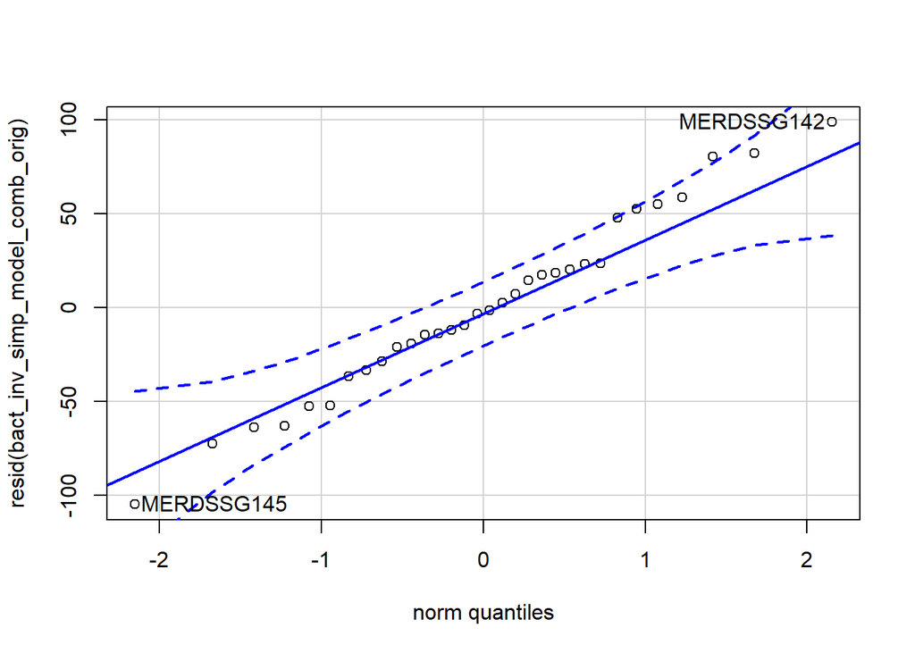

```
## MERDSSG145 MERDSSG142
##         11         10
```

```r
qqPlot(resid(bact_inv_simp_model_comb_orig))
```

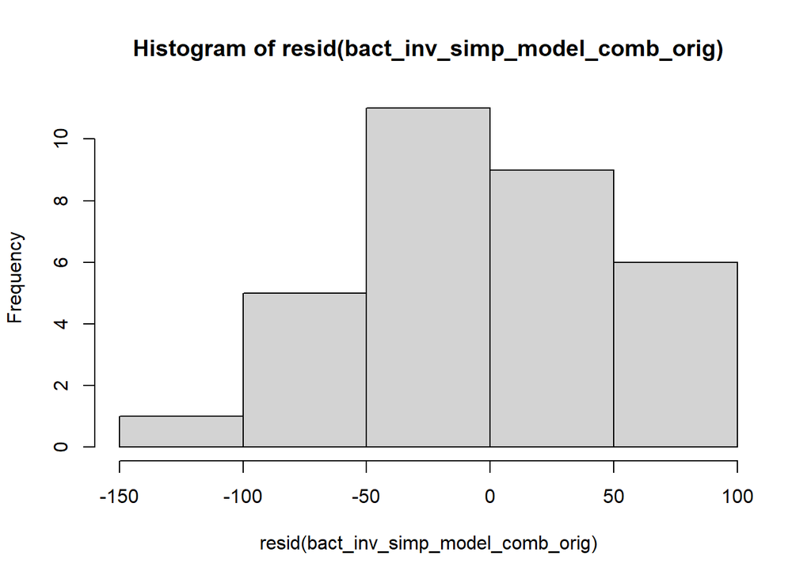

```r
hist(resid(bact_inv_simp_model_comb_orig))
```

```r
shapiro.test(resid(bact_inv_simp_model_comb_orig))
```

```
##
##  Shapiro-Wilk normality test
##
## data:  resid(bact_inv_simp_model_comb_orig)
## W = 0.98752, p-value = 0.9655
```

Raw Statistical output

```r
anova(bact_inv_simp_model_comb_orig)
```

```
## Type III Analysis of Variance Table with Satterthwaite's method
##                              Sum Sq Mean Sq NumDF DenDF F value  Pr(>F)
## soil_root                   19081.3 19081.3     1    24  6.4055 0.01834 *
## precip                       2769.6  2769.6     1    24  0.9298 0.34454
## life_stage                    881.1   881.1     1    24  0.2958 0.59155
## soil_root:precip             6252.0  6252.0     1    24  2.0988 0.16036
## soil_root:life_stage         9174.0  9174.0     1    24  3.0797 0.09204 .
## precip:life_stage            1330.4  1330.4     1    24  0.4466 0.51033
## soil_root:precip:life_stage  7580.8  7580.8     1    24  2.5449 0.12374
## ---
## Signif. codes:  0 '***' 0.001 '**' 0.01 '*' 0.05 '.' 0.1 ' ' 1
```

```r
emmeans(bact_inv_simp_model_comb_orig, pairwise~soil_root|precip)
```

```
## NOTE: Results may be misleading due to involvement in interactions
```

```
## Note: Use 'contrast(regrid(object), ...)' to obtain contrasts of back-transformed estimates
```

```
## $emmeans
## precip = A:
##  soil_root emmean   SE   df lower.CL upper.CL
##  L.B         41.0 19.3 20.8    0.803     81.1
##  L.R        117.8 19.3 20.8   77.597    157.9
##
## precip = D:
##  soil_root emmean   SE   df lower.CL upper.CL
##  L.B         50.3 19.3 20.8   10.152     90.5
##  L.R         71.2 19.7 19.4   29.931    112.4
##
## Results are averaged over the levels of: life_stage
## Degrees-of-freedom method: kenward-roger
## Results are given on the ( (not the response) scale.
## Confidence level used: 0.95
##
## $contrasts
## precip = A:
##  contrast  estimate   SE   df t.ratio p.value
##  L.B - L.R    -76.8 27.3 21.0 -2.814  0.0104
##
## precip = D:
##  contrast  estimate   SE   df t.ratio p.value
##  L.B - L.R    -20.9 27.6 21.7 -0.757  0.4575
##
## Results are averaged over the levels of: life_stage
## Note: contrasts are still on the ( scale
## Degrees-of-freedom method: kenward-roger
```

Formatted Anova table

|  | Df | Resid.Df | F.value | P.value |
| --- | --- | --- | --- | --- |
| soil_root | 1 | 24 | 6.41 | 0.018 |
| precip | 1 | 24 | 0.93 | 0.345 |
| life_stage | 1 | 24 | 0.30 | 0.592 |
| soil_root:precip | 1 | 24 | 2.10 | 0.160 |
| soil_root:life_stage | 1 | 24 | 3.08 | 0.092 |
| precip:life_stage | 1 | 24 | 0.45 | 0.510 |
| soil_root:precip:life_stage | 1 | 24 | 2.54 | 0.124 |